# bugs_love_summers

```r
# import data
mosquito <- read_csv("data/aegypti_albopictus.csv",
    col_types = cols(VECTOR = col_factor(levels = c("Aedes aegypti",
        "Aedes albopictus"))))
# view the file
# head(mosquito, n=3)
```

## Original column names

- VECTOR: Identifying the species; Ae. aegypti or Ae. albopictus
- OCCURRENCE_ID: Unique identiﬁer for each occurrence in the database after temporal and spatial standardisation.
- SOURCE_TYPE: Published literature or unpublished sources with reference ID that corresponds to the full list of references in Data Citation 1.
- LOCATION_TYPE: Whether the record represents a point or a polygon location.
- POLYGON_ADMIN: Admin level or polygon size which the record represents when the location type is a polygon. −999 when the location type is a point (5km×5km).
- X: The longitudinal coordinate of the point or polygon centroid (WGS1984 Datum).
- Y: The latitudinal coordinate of the point or polygon centroid (WGS1984 Datum).
- YEAR: The year of the occurrence.
- COUNTRY: The name of the country within which the occurrence lies.
- COUNTRY_ID: ISO alpha-3 country codes.
- GAUL_AD0: The country-level global administrative unit layer (GAUL) code (see http://www.fao. org/geonetwork) which identiﬁes the Admin-0 polygon within which any smaller polygons and points lie.
- STATUS: Established versus transient populations.

| bug | occurrence_id | source_type | location_type | polygon_admin | long | lat | year | country | country_id | gaul_ad0 | status |
| --- | --- | --- | --- | --- | --- | --- | --- | --- | --- | --- | --- |
| Aedes aegypti | 1 | published | point | -999 | -3.22 | 40.07 | 1958 | Kenya | KEN | 133 | NA |
| Aedes aegypti | 2 | published | point | -999 | -4.27 | 15.30 | 1960 | Congo | COG | 59 | NA |
| Aedes aegypti | 3 | published | point | -999 | -4.27 | 15.30 | 1960 | Congo | COG | 59 | NA |
| Aedes aegypti | 4 | published | point | -999 | -3.22 | 40.07 | 1960 | Kenya | KEN | 133 | NA |
| Aedes aegypti | 5 | published | point | -999 | -3.04 | 40.14 | 1960 | Kenya | KEN | 133 | NA |

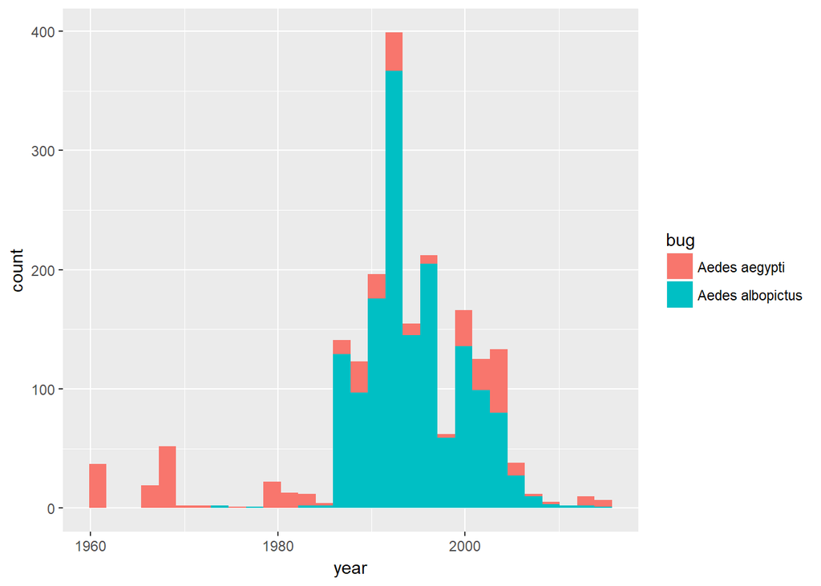

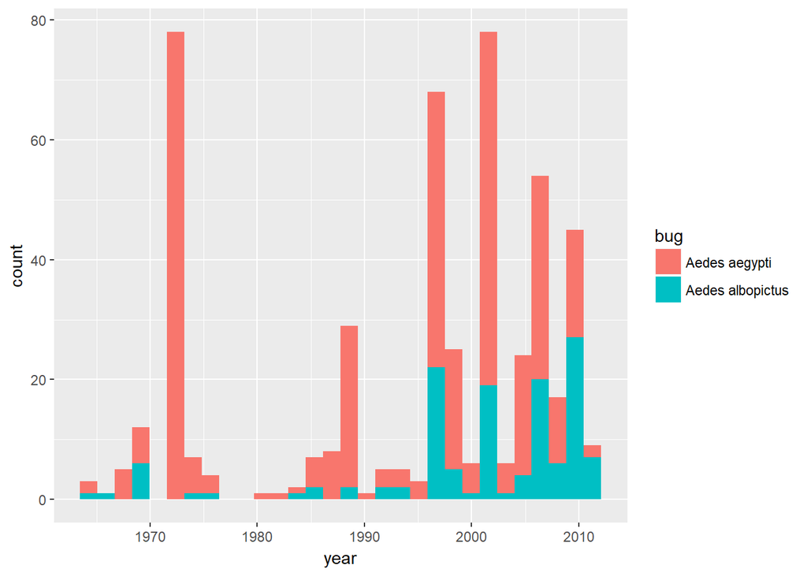